# Using nestedRanksTest

Douglas G. Scofield

2015-06-06

Tne `nestedRanksTest` package provides functions for performing a Mann-Whitney-Wilcoxon-type nonparametric test for a difference between treatment levels using nested ranks, together with functions for displaying results of the test. The nested ranks test may be used when observations are structured into several groups and each group has received both treatment levels. The p-value is determined via bootstrapping.

The `nestedRanksTest` is intended to be one possible mixed-model extension of the Mann-Whitney-Wilcoxon test, for which treatment is a fixed effect and group membership is a random effect. The standard Mann-Whitney-Wilcoxon test is available in R as [`wilcox.test`](https://stat.ethz.ch/R-manual/R-patched/library/stats/html/wilcox.test.html).

We first described the nested ranks test in detail in the supplemental information of Thompson *et al*. (2014). Here we consider an example case, the results of which were first presented in that paper.

# Background

Together with my colleagues Pamela Thompson, Peter Smouse and Victoria Sork, we were examining year-to-year differences in acorn movement by acorn woodpeckers in an oak savannah in central California. Drs Sork and Smouse have collaborated for several years studying patterns of genetic diversity in oak populations, unraveling the ways in which genetic diversity moves around the landscape via dispersal of pollen and seeds. This work usually involves the development of analytic methods to help study patterns of dispersal.

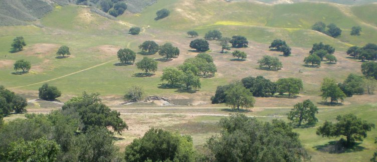

Oaks are [mast-seeding](http://www.hastingsreserve.org/oakstory/AmerSciMastKoenig_05.pdf) species; their acorn production can vary a great deal from year to year. One of the questions we asked during our year-to-year comparisons was: Do woodpeckers forage for acorns farther from their granaries during years of low acorn production? This is a common-sense prediction from [optimal foraging theory](http://en.wikipedia.org/wiki/Optimal_foraging_theory): if there is food available close to home, why travel far? In years of high acorn production, acorns tend to be readily available throughout the landscape, but time and energy are saved by foraging from trees closer to the granary. When acorn production is low, more travel is required to find acorns, and woodpeckers are likely to gather acorns from trees that are on average farther away from their granaries.

# Initial analyses

First, we prepare our datasets and generate tables to see what our sample sizes are.

```r
library(nestedRanksTest)
data(woodpecker_multiyear)
d.Qlob <- subset(woodpecker_multiyear, Species == "lobata")
d.Qagr <- subset(woodpecker_multiyear, Species == "agrifolia")
table(d.Qlob$Year, d.Qlob$Granary)
```

```
#>
#>         9 10 33 39 48 107 163 532 912
#>   2002 11 17  9 14  3  16   8  11  14
#>   2004 12 21 15 14  9   7  15   9  13
```

```r
table(d.Qagr$Year, d.Qagr$Granary)
```

```
#>
#>        10 31 140 151 152 938 942
#>   2006 12 10   8  47  49  47  44
#>   2007 14 15  10  10  20  20  10
```

We create exploratory plots to see if any obvious structure appears. Relatively few seed movements are longer than 500 m:

```r
sum(d.Qlob$Distance > 500)
```

```
#> [1] 3
```

```r
sum(d.Qagr$Distance > 500)
```

```
#> [1] 8
```

so for clarity we exclude outliers from these plots. To reduce overplotting and give us a better sense of acorn numbers at each distance, we also jitter the y-position of the points just a bit.

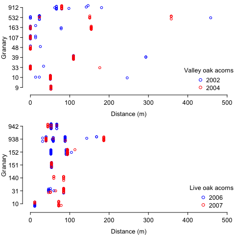

```r
opa <- par(mfcol = c(2, 1), cex = 0.8, mar = c(3, 3, 0, 0), las = 1,
           mgp = c(2, 0.5, 0), tcl = -0.3)
stripchart(Distance ~ Granary, data = d.Qlob, subset = Year == "2002",
           xlab = "Distance (m)", ylab = "Granary", pch = 1, col = "blue",
           method = "jitter", jitter = 0.2, xlim = c(0, 500),
           frame.plot = FALSE)
stripchart(Distance ~ Granary, data = d.Qlob, subset = Year == "2004",
           pch = 1, col = "red", method = "jitter", jitter = 0.2, add = TRUE)
legend("bottomright", legend = c("2002", "2004"), pch = 1, bty = "n",
       col = c("blue", "red"), title = "Valley oak acorns")
stripchart(Distance ~ Granary, data = d.Qagr, subset = Year == "2006",
           xlab = "Distance (m)", ylab = "Granary", pch = 1, col = "blue",
           method = "jitter", jitter = 0.2, xlim = c(0, 500),
           frame.plot = FALSE)
stripchart(Distance ~ Granary, data = d.Qagr, subset = Year == "2007",
           pch = 1, col = "red", method = "jitter", jitter = 0.2, add = TRUE)
legend("bottomright", legend = c("2006", "2007"), pch = 1, bty = "n",
       col = c("blue", "red"), title = "Live oak acorns")
par(opa)
```

Seeds moved 0 m (always valley oak) were harvested from the same tree that hosted the granary.

There do appear to be between-year differences for each oak species, but clearly there is also a lot of granary-specific structure. This occurs because each granary has its own neighbourhood of oak trees at varying distances, and the territorial acorn woodpeckers are most likely to forage in their specific neighbourhood and have a neighbourhood-specific collection of seed movement distances (Scofield *et al*. 2010, Scofield *et al*. 2011, Thompson *et al*. 2014). The `woodpecker_multiyear` dataset does not include seed source tree identities, but we can treat each unique distance as the identity of a unique tree because of the relative sparseness of the trees in the landscape. Calculating the median distance to seed trees used, we do see a great deal of variation.

```r
with(d.Qlob, unlist(lapply(lapply(split(Distance, Granary), unique), median)))
```

```
#>      9     10     33     39     48    107    163    532    912
#>  52.00  36.70  33.40 442.80  25.20   6.55  45.70 150.80  97.80
```

```r
with(d.Qagr, unlist(lapply(lapply(split(Distance, Granary), unique), median)))
```

```
#>      10      31     140     151     152     938     942
#>   71.85   59.80 1343.90   53.60   94.00   88.10   52.60
```

We discussed the unusually long acorn movement distances of coast live oak for granary 140 in Scofield *et al*. (2010).

Because of the variation in distances, a nonparametric test such as the Mann-Whitney-Wilcoxon test ([`wilcox.test`](https://stat.ethz.ch/R-manual/R-patched/library/stats/html/wilcox.test.html)) is preferred to a parametric test such as `t.test`.

```r
wilcox.test(Distance ~ Year, data = d.Qlob)
```

```
#>
#>  Wilcoxon rank sum test with continuity correction
#>
#> data:  Distance by Year
#> W = 5277.5, p-value = 0.1585
#> alternative hypothesis: true location shift is not equal to 0
```

```r
wilcox.test(Distance ~ Year, data = d.Qagr)
```

```
#>
#>  Wilcoxon rank sum test with continuity correction
#>
#> data:  Distance by Year
#> W = 7600, p-value = 2.782e-05
#> alternative hypothesis: true location shift is not equal to 0
```

The results reveals significant differences for live oak but not valley oak. However, this approach is unsatisfying because it ignores spatial structure we can see in the data. One possibility might be to test for year-to-year differences for each granary individually. For brevity we examine just the p-values for each test:

```r
wilcox.p.value <- function(x) wilcox.test(Distance ~ Year, data = x, exact = FALSE)$p.value
round(unlist(lapply(split(d.Qlob, d.Qlob$Granary), wilcox.p.value)), 4)
```

```
#>      9     10     33     39     48    107    163    532    912
#>    NaN 0.5302 0.8036 0.0378 0.0157 0.3740 0.0079 0.0081 0.2970
```

```r
round(unlist(lapply(split(d.Qagr, d.Qagr$Granary), wilcox.p.value)), 4)
```

```
#>     10     31    140    151    152    938    942
#> 0.0004 0.0054 0.0003    NaN 0.0000 0.0942 0.0004
```

This solution is still not satisfying. The sample sizes are too small for convincing single-granary results, there is clearly some issue with assumptions of `wilcox.test` (note the `NaN` values for some p-values), and the answers do not fit the scale of our original question: are there *overall* differences in seed movement between high- and low-crop years? We could find or develop a technique to combine the p-values, but this is still off the mark.

A better test would allow for differences between granaries, while testing for the aggregate between-year difference in acorn movement distances about which we are curious. In model terms, a better test would evaluate all data together while treating year as a fixed effect and granary as a random effect, akin to a [mixed model](http://en.wikipedia.org/wiki/Mixed_model). This was our motivation for developing `nestedRanksTest`.

# Using the test

The `nestedRanksTest` takes three variables:

- Continuous response, named `y`
- Treatment factor with exactly two levels, named `x`, this will be coerced to a factor if it is not already
- Grouping factor, named `groups`, this too will be coerced to a factor

There are two interfaces for the test:

- a formula interface, the simplest to use, takes a formula of the form `y ~ x | groups` and includes `data` and `subset` arguments
- a default interface, that accepts `x`, `y` and `groups` as separate arguments

The grouping factor may be provided using the `groups =` argument in either the formula or default interfaces. This argument can be used when the formula has the form `y ~ x`. All of the following are valid and produce identical results.

```r
result <- nestedRanksTest(Distance ~ Year | Granary, data = d.Qlob)
result <- nestedRanksTest(Distance ~ Year, groups = Granary, data = d.Qlob)
## Because no data= for default interface, here we use with()
result <- with(d.Qlob, nestedRanksTest(Year, Distance, Granary))
result <- with(d.Qlob, nestedRanksTest(y = Distance, x = Year, groups = Granary))
```

The grouping factor is required, and it is an error to provide a grouping factor twice using both the formula and the argument.

```r
## Error: 'groups' missing
result <- with(d.Qlob, nestedRanksTest(Year, Distance))
```

[output not shown]

```r
result <- nestedRanksTest(Distance ~ Year, data = d.Qlob)
```

[output not shown]

```r
result <- nestedRanksTest(Distance ~ Year | Granary, groups = Granary, data = d.Qlob)
```

# Examining results

The return value of `nestedRanksTest` is a list of class `'htest_boot'`, a class which extends the often-used class `'htest'`. `print` and `plot` methods are provided.

```r
result.Qlob <- nestedRanksTest(Distance ~ Year | Granary, data = d.Qlob, n.iter = 2000)
print(result.Qlob)
```

```
#>
#>  Nested Ranks Test
#>
#> data:  Distance by Year grouped by Granary
#> Z = 0.080882, p-value = 0.0635
#> alternative hypothesis: Z lies above bootstrapped null values
#> null values:
#>       0%       1%       5%      10%      25%      50%      75%      90%
#> -0.15735 -0.11546 -0.08676 -0.06919 -0.03474 -0.00074  0.03529  0.06772
#>      95%      99%     100%
#>  0.08824  0.12280  0.19853
#>
#> bootstrap iterations: 2000
#> group weights:
#>          9         10         33         39         48        107        163
#> 0.09705882 0.26250000 0.09926471 0.14411765 0.01985294 0.08235294 0.08823529
#>        532        912
#> 0.07279412 0.13382353
```

```r
#
#
result.Qagr <- nestedRanksTest(Distance ~ Year | Granary, data = d.Qagr, n.iter = 2000)
print(result.Qagr)
```

```
#>
#>  Nested Ranks Test
#>
#> data:  Distance by Year grouped by Granary
#> Z = 0.27695, p-value = 0.001
#> alternative hypothesis: Z lies above bootstrapped null values
#> null values:
#>       0%       1%       5%      10%      25%      50%      75%      90%
#> -0.20818 -0.15307 -0.11152 -0.08643 -0.04523 -0.00062  0.04678  0.08708
#>      95%      99%     100%
#>  0.10967  0.16576  0.29306
#>
#> bootstrap iterations: 2000
#> group weights:
#>         10         31        140        151        152        938        942
#> 0.05204461 0.04646840 0.02478315 0.14560099 0.30359356 0.29120198 0.13630731
```

We can also plot the results.

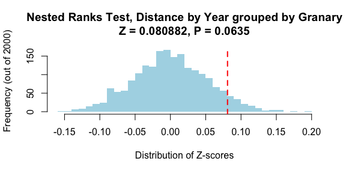

```r
plot(result.Qlob)
```

Titles, colours, line styles, etc. may be modified.

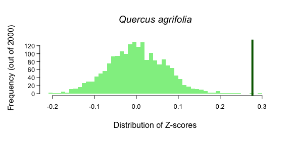

```r
plot(result.Qagr, main = expression(italic("Quercus agrifolia")),
     col = "lightgreen", p.col = "darkgreen", p.lty = 1, p.lwd = 4,
     mgp = c(2.5, 0.5, 0), cex.axis = 0.8, las = 1, tcl = -0.3)
```

# Return value

The return value of `nestedRanksTest` is a list of class `'htest_boot'`, which extends the often-used class `'htest'` by including some members that allow for further description of the bootstrap process and null distribution. Components marked with `"*"` are additions to `'htest'`.

| Component | Contents |
| --- | --- |
| `statistic` | the value of the observed Z-score. |
| `p.value` | the p-value for the test. |
| `alternative` | a character string describing the alternative hypothesis. |
| `method` | a character string indicating the nested ranks test performed. |
| `data.name` | a character string giving the name(s) of the data.. |
| `bad.obs` | the number of observations in the data excluded because of `NA` values. |
| `null.values` | quantiles of the null distribution used for calculating the p-value. |
| `n.iter*` | the number of bootstrap iterations used for generating the null distribution. |
| `weights*` | the weights for groups, calculated by `nestedRanksTest_weights`. |
| `null.distribution*` | vector containing null distribution of Z-scores, with `statistic` the last value. |

The length of `null.distribution` equals `n.iter`. Note that `null.distribution` will not be present if the `lightweight = TRUE` option was given to `nestedRanksTest`.

The structure of the class is:

```r
str(result.Qlob)
```

```
#> List of 10
#>  $ statistic        : Named num 0.0809
#>   ..- attr(*, "names")= chr "Z"
#>  $ p.value          : num 0.0635
#>  $ alternative      : chr "Z lies above bootstrapped null values"
#>  $ method           : chr "Nested Ranks Test"
#>  $ data.name        : chr "Distance by Year grouped by Granary"
#>  $ bad.obs          : int 0
#>  $ null.values      : Named num [1:11] -0.1573 -0.1155 -0.0868 -0.0692 -0.0347 ...
#>   ..- attr(*, "names")= chr [1:11] "0%" "1%" "5%" "10%" ...
#>  $ n.iter           : num 2000
#>  $ weights          : Named num [1:9] 0.0971 0.2625 0.0993 0.1441 0.0199 ...
#>   ..- attr(*, "names")= chr [1:9] "9" "10" "33" "39" ...
#>  $ null.distribution: num [1:2000] -0.04632 0.02426 0.01838 -0.00294 -0.04191 ...
#>  - attr(*, "class")= chr [1:2] "htest_boot" "htest"
```

# Details

In brief, group-specific between-treatment Z-scores are calculated, a bootstrap distribution of Z-scores is calculated for each group by using the same procedure but with ranks shuffled without regard to treatment, then the observed and bootstrapped Z-scores are aggregated by weighting each group’s contribution by sample size.

## Z-statistic

Values across both treatments are ranked using the base R function `rank` with `ties.method = "average"`, which assigns tied values their average rank. The Mann-Whitney-Wilcoxon test statistic is computed from these ranks. The value of this statistic is sample-size dependent, between -*n*<sub>1</sub>×*n*<sub>2</sub> and *n*<sub>1</sub>×*n*<sub>2</sub>, where *n*<sub>1</sub> and *n*<sub>2</sub> are group-specific sample sizes for each treatment level. The statistic is scaled to [-1, +1] by dividing by *n*<sub>1</sub>×*n*<sub>2</sub>.

Help for the function performing this calculation is available via `?nestedRanksTest_Z` and its code can be examined directly with:

```r
nestedRanksTest::nestedRanksTest_Z
```

## Bootstrap procedure

The bootstrap procedure is performed for each group separately. For each bootstrap iteration, response values are shuffled without regard to treatment using the base R function `sample` with `replace = FALSE`. The Z-statistic is calculated using the above procedure while maintaining the same *n*<sub>1</sub> and *n*<sub>2</sub> values. This is repeated `n.iter - 1` times for each group, and the bootstrapped Z-statistics are placed in a vector with the observed Z-statistic as the `n.iter`-th value. The vectors for each group are collected into the columns of a matrix.

## Group weights

Weights are calculated for each group by multiplying the treatment-specific sample sizes for each group (*n*<sub>1</sub>×*n*<sub>2</sub>), and then dividing each by the sum of *n*<sub>1</sub>×*n*<sub>2</sub> for all groups. Thus the weights sum to 1.

Help for the function performing this calculation is available via `?nestedRanksTest_weights` and its code can be examined directly with:

```r
nestedRanksTest::nestedRanksTest_weights
```

The return value is a `data.frame` with group-specific information including weights and sample sizes in each treatment.

## Aggregate Z-score and p-value

The aggregate Z-core for the observed data and each bootstrap iteration are calculated by multiplying each row of the matrix described in the bootstrap procedure by the weights, and then summing the values in each row, resulting in a vector of aggregate Z-scores of length `n.iter` with the Z-score for the observed data as the `n.iter`-th value. This vector is returned in the `null.distribution` element of class `'htest_boot'`, but is not returned if the `lightweight = TRUE` option was used when invoking `nestedRanksTest`.

The p-value is calculated by counting the number of elements in the vector greater than or equal to the Z-score for the observed data. Because the observed Z-score is an element of this vector, the p-value can never be less than 1 / `n.iter`.

These statistical tools were developed in collaboration with Peter E. Smouse (Rutgers University) and Victoria L. Sork (UCLA) and were funded in part by U.S. National Science Foundation awards NSF-DEB-0514956 and NSF-DEB-0516529.

# References

Details are also available in Appendix A of the the supplemental information for Thompson *et al*. (2014), while the code in this package is updated and expanded from that in Appendix B of the same supplemental information.

Scofield, D. G., Sork, V. L., and Smouse, P. E. (2010) Influence of acorn woodpecker social behaviour on transport of coast live oak (*Quercus agrifolia*) acorns in a southern California oak savanna. [*Journal of Ecology* **98**: 561-572](http://dx.doi.org/10.1111/j.1365-2745.2010.01649.x).

Scofield, D. G., Alvaro, V. R., Sork, V. L., Grivet, D., Martinez, E., Pluess, A., Koenig, W. D. and Smouse, P. E. (2011) Foraging patterns of acorn woodpeckers (*Melanerpes formicivorus*) on valley oak (*Quercus lobata* Née) in two California oak savannah-woodlands. [*Oecologia* **168**: 187-196](http://dx.doi.org/10.1007/s00442-010-1828-5).

Thompson, P. G., Smouse, P. E., Scofield, D. G., and Sork, V. L. (2014) What seeds tell us about birds: a multi-year analysis of acorn woodpecker foraging movements. [*Movement Ecology* **2**: 12](http://www.movementecologyjournal.com/content/2/1/12).